# Bay Wheels Trip Data Exploration

## Preliminary Wrangling

## A. Introduction

- Owned by Lyft, Bay Wheels is a bike-sharing company operating in the Bay Area. It first launched in 2013, later became one of the most welcomed bike-sharing services on the west coast in the U.S, and was acquired by Lyft in 2019.

[figure not shown]

### What is the structure of your dataset?

There are 519700 rows and 23 columns in the data set.

### What is/are the main feature(s) of interest in your dataset?

I'm most interested in figuring out what features affect the rentals and how generally the process of trips.

### What features in the dataset do you think will help support your investigation into your feature(s) of interest?

I expect that user-type and all date time variables eg. months, duration_min etc. will play a big role in my data analysis.

## Univariate Exploration

### How are the user types distributed?

[figure not shown]

```python
# plot pie chart
sorted_counts = df['user_type'].value_counts(normalize=True)
plt.figure(figsize = [12, 8])
labels = ['Customer', 'Subscriber']
plt.pie(sorted_counts , labels = sorted_counts.index,
       startangle = 90 , counterclock = False , autopct='%1.1f%%');
plt.title('User Type Breakdown' , fontsize=30 , ha='center')
plt.legend(labels,loc=3 , fontsize=10)
plt.show()
```

- Looks like majority of the users are subscribers

## Duration per Ride

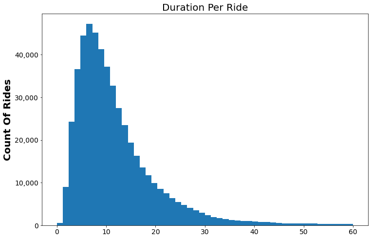

```python
#plot the histogram and tweak the plot
plt.hist(df['duration_min'], bins = 50, range = (0, 60))
plt.xticks(size = 14)
plt.yticks(size = 14)
plt.title("Duration Per Ride", size = 20)
# Add y label and format it
plt.ylabel('Count of rides'.title(),
               fontsize = 20, weight = "bold")
plt.gcf().set_size_inches(12,8)
plt.gca().get_yaxis().set_major_formatter(ticker.FuncFormatter(lambda x, p: format(int(x), ',')))
plt.gca().get_xaxis().set_major_formatter(ticker.FuncFormatter(lambda x, p: format(int(x), ',')))

plt.show()
```

### Discuss the distribution(s) of your variable(s) of interest. Were there any unusual points? Did you need to perform any transformations?

All the duration_min variable had large number of values the plot i used was enough to show me the duration of most rides, I therefore didnt think it was necessary for any transformations.

### Of the features you investigated, were there any unusual distributions? Did you perform any operations on the data to tidy, adjust, or change the form of the data? If so, why did you do this?

Fisrt I had present in the data duration_sec variable. I therefore created another column duration_min which I though was more realistic. There were a couple of outliers in the duration min variable but overall it showed what was desired.

## Multivariate

[figure not shown]

```python
#creating daily rental count dataset
rental_by_day = df.groupby('date').count()['user_type']

#changing theme to seaborn and creating the plot
plt.style.use('seaborn')
plt.plot(rental_by_day)

#modifying x-ticks and y-ticks, and adding titles
plt.xticks(rotation=90, size = 14)
plt.yticks(size = 14)
plt.ylim(0,8000)
plt.title("Daily Rental (April To December 2017)", size = 20)
plt.gca().get_yaxis().set_major_formatter(ticker.FuncFormatter(lambda x, p: format(int(x), ',')))
tick_spacing = 4
plt.gca().xaxis.set_major_locator(ticker.MultipleLocator(tick_spacing))

#set figure to a larger size
plt.gcf().set_size_inches(12,8)

#adding bandwidths for weekends
for i in rental_by_day.index[rental_by_day.index.weekday == 5]:
    plt.axvspan(i, i+timedelta(days=2),color='red', alpha=0.12)

plt.show()
```

### Observation

- It appears that weekends tend to have lower rentals than weekdays.

### Number of User Type by Weekday

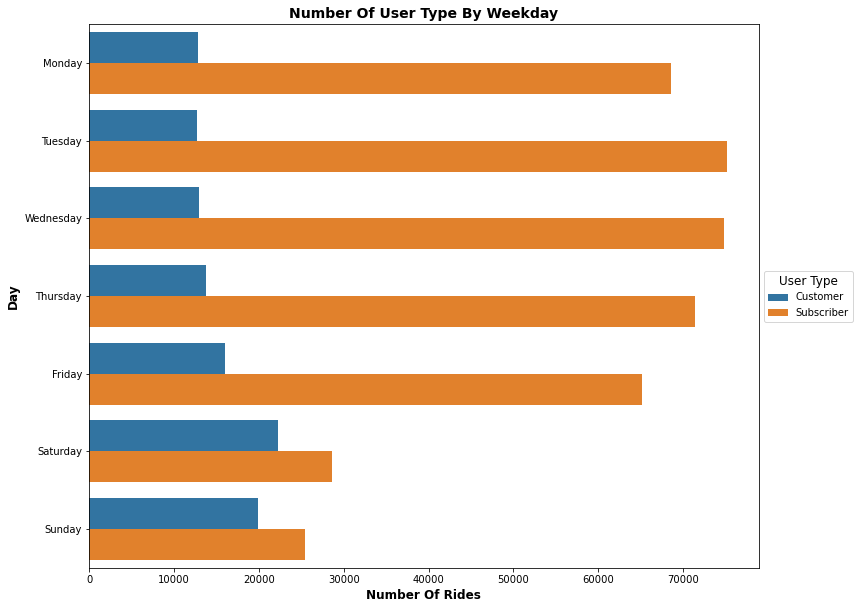

```python
plt.figure(figsize=[12, 10])

sb.countplot(data = df, y='dayofweek_start', hue = 'user_type');


# Add title and format it
plt.title("Number of user type by weekday".title(),
               fontsize = 14, weight = "bold")
# Add x label and format it
plt.xlabel('Number of rides'.title(),
               fontsize = 12, weight = "bold")
# Add y label and format it
plt.ylabel('Day'.title(),
               fontsize = 12, weight = "bold")

plt.legend(loc='center left', bbox_to_anchor=(1, 0.5),
           title="User Type", title_fontsize = 12);
```

### Observations

- It generally looks like subscribers rent bikes or ride more than customers.
- Also you can feel that subscribers tend to rent or ride less during the weekends.
- Surprisingly compared to weekdays, it appears that customers would be renting or riding more during the weekends.

### Duration of minutes per month.

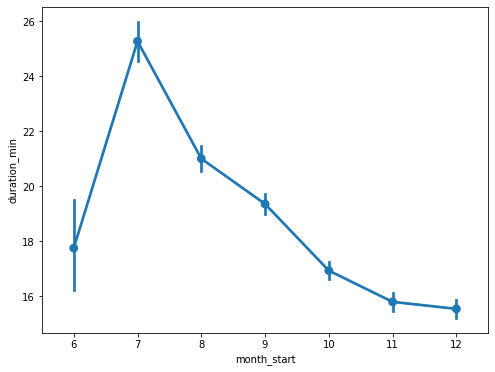

```python
# Plot the pointplot
plt.figure(figsize = (8,6))
base_color = sb.color_palette()[0]
sb.pointplot(data = df, x = 'month_start', y = 'duration_min', color = base_color, linestyles = '-');
```

### Most frequent origins of start

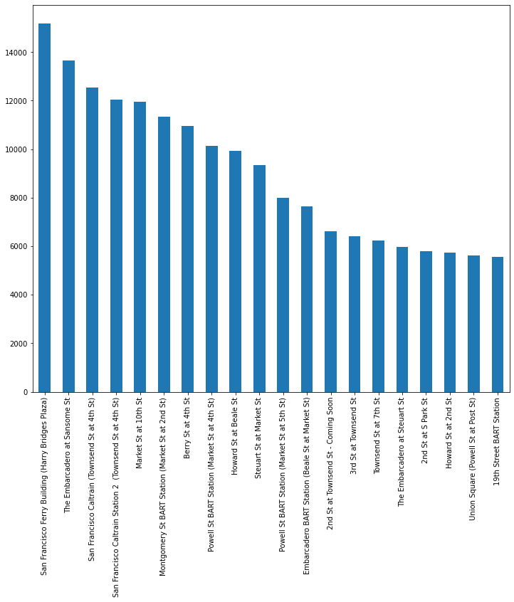

```python
plt.figure(figsize=(12,10))
default_color = sb.color_palette()[0]

df['start_station_name'].value_counts().head(20).plot(kind='bar', color = default_color);
```

### Observation

Looks like the most frequent starting origins are:

Harry Bridges Plaza

The Embarcadero at Sansome St

San Fransisco Caltrain

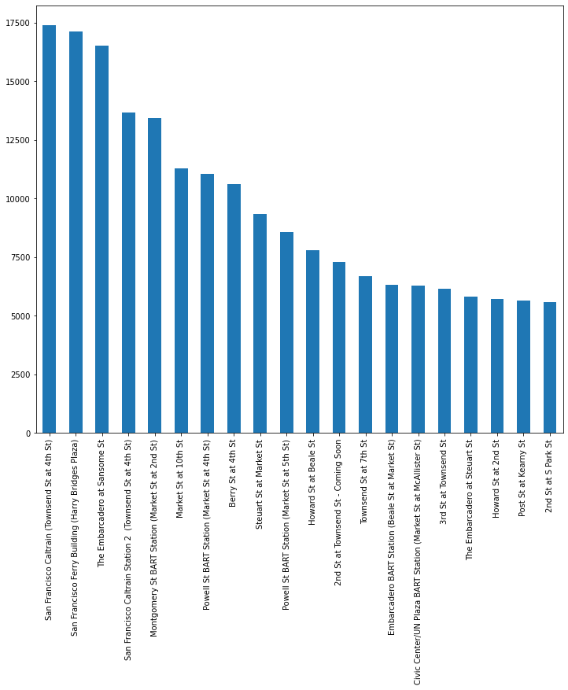

```python
plt.figure(figsize=(12,10))
default_color = sb.color_palette()[0]

df['end_station_name'].value_counts().head(20).plot(kind='bar', color = default_color);
```

### Most frequent destinations

In contrast the most frequet destinations are:

- Townsend St at 4th St
- Harry bridges plaza
- The Embarcadero at Sansome St

### When are bikes mostly rented out?

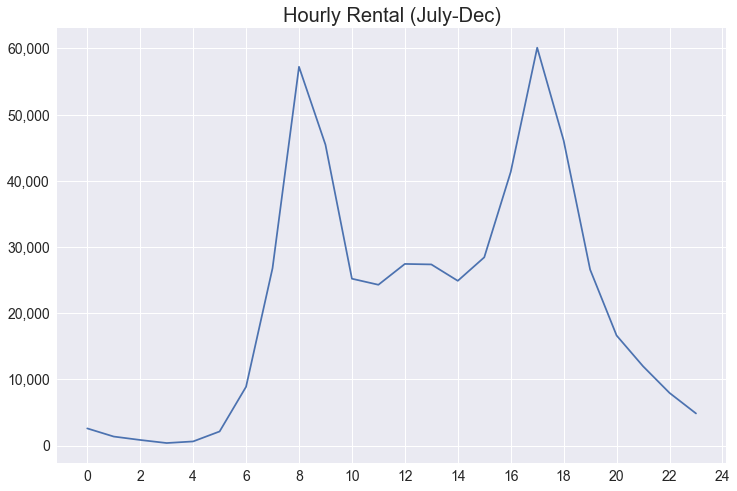

```python
#create the grouped dataset
df['hour'] = df.start_time.dt.hour
hourly = df.groupby('hour').count().user_type

#plot the line chart and further tweak the plot
plt.plot(hourly)
plt.xticks(size = 14)
plt.yticks(size = 14)
plt.title("Hourly Rental (July-Dec)", size = 20)
plt.gca().get_yaxis().set_major_formatter(ticker.FuncFormatter(lambda x, p: format(int(x), ',')))
tick_spacing = 2
plt.gca().xaxis.set_major_locator(ticker.MultipleLocator(tick_spacing))
plt.gcf().set_size_inches(12,8)

plt.show()
```

### Talk about some of the relationships you observed in this part of the investigation. How did the feature(s) of interest vary with other features in the dataset?

A couple of interesting points here:

- The month of July recorded the highest average minutes in terms of duration_min vs month.
- Surprisingly there was a negative correlation between weekends and count of rides. It appeared as though most rentals or rides occurred on weekdays.
- There were 2 peaks of hourly rentals.
- Subscribers rented bikes much more than customers

### Did you observe any interesting relationships between the other features (not the main feature(s) of interest)?

- Nothing out of the ordinary.

## Multivariate Exploration

The main thing I want to explore in this part of the analysis is how duration min, user type and Weekday corrlate.

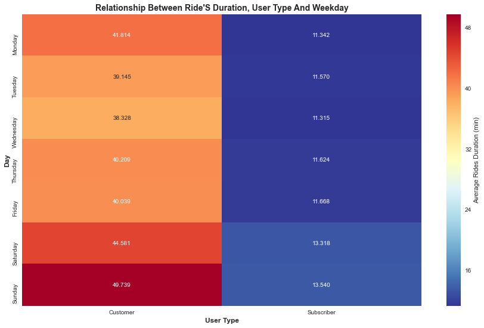

```python
plt.figure(figsize=[15, 9])

#--Calculating the average of ride's duration
#--Transforming the data in a pivot table to plot the heatmap
cat_means = df.groupby(['user_type','dayofweek_start']).mean()['duration_min']
cat_means = cat_means.reset_index(name = 'duration_min_avg')
cat_means = cat_means.pivot(index = 'dayofweek_start', columns = 'user_type',
                            values = 'duration_min_avg')
sb.heatmap(cat_means, annot = True, fmt = '.3f',
           cbar_kws = {'label':'Average Rides Duration (min)'}, cmap = 'RdYlBu_r')


# Add title and format it
plt.title("Relationship between ride's duration, user type and weekday".title(),
               fontsize = 14, weight = "bold")
# Add x label and format it
plt.xlabel('User Type'.title(),
               fontsize = 12, weight = "bold")
# Add y label and format it
plt.ylabel('Day'.title(),
               fontsize = 12, weight = "bold");
```

## Observation

- Customers spent more time on rides mostly on Sunday.
- In general Sunday seems to be the day people spend time most on bikes.

### What can we say about the end stations?

[figure not shown]

```python
# plot map
fig, ax = plt.subplots(figsize = (15,12))
ax.scatter(df.end_station_longitude, df.end_station_latitude, zorder=1, alpha= 0.2, c='b', s=10)
ax.set_title('Map of End Stations' , size=14)
ax.set_xlim(BBox[0],BBox[1])
ax.set_ylim(BBox[2],BBox[3])
ax.imshow(mymap, zorder=0, extent = BBox, aspect= 'equal');
```

### Observations

- Most destinations were on Sanjose and San Fransico.

### Were there any interesting or surprising interactions between features?

We observed on map that most destinations were downtown, in sanjose and uptown in sanfransisco.